# stock_picker

The purpose of this file is to use evaluate stocks against some selection criteria to evaluate if the stock could be a potential buy. This is done by applying a logic that checks that some condition is fulfilled for each stock.

Set today´s date as a variable

```r
today <- Sys.Date()
```

Loading required packages

### Tidyquant and other

```r
library(tidyquant) # for pulling stock quotes with tq_get()
library(zoo)       # for calculating rolling mean with rollmean()
library(tidyverse) # for plotting
# Documentation:
# https://cran.r-project.org/web/packages/tidyquant/vignettes/TQ01-core-functions-in-tidyquant.html
```

###Pull stock info

```r
# Docs: https://cran.r-project.org/web/packages/tidyquant/vignettes/TQ01-core-functions-in-tidyquant.html

# check what indexes we have in tidyquant
tq_index_options() # DOW, DOWGLOBAL, SP400, SP500, SP600
```

```
[1] "DOW"       "DOWGLOBAL" "SP400"     "SP500"     "SP600"
```

```r
index_list <- tq_index_options()
x <- 1 # the first exchange in the list e.g 1 = "DOW" or 4 = "SP500" (too many to plot in one session)
#x <- 2 # "DOWGLOBAL", tq_get() failed on "MT-NL"

# get quotes one index
tq_index("DOWGLOBAL")
```

```
Getting holdings for DOWGLOBAL
```

| symbol | company | identifier | sedol | weight | sector | shares_held | local_currency |
| --- | --- | --- | --- | --- | --- | --- | --- |
| COP | ConocoPhillips | 20825C10 | 2685717 | 0.0125083939 | Energy | 13127 | USD |
| XOM | Exxon Mobil Corporation | 30231G10 | 2326618 | 0.0124366080 | Energy | 13563 | USD |
| CVX | Chevron Corporation | 16676410 | 2838555 | 0.0117217807 | Energy | 7639 | USD |
| SLB | Schlumberger NV | 80685710 | 2779201 | 0.0102066756 | Energy | 27336 | USD |
| BA-GB | BAE Systems plc | 026349 | 0263494 | 0.0100479634 | Industrials | 95314 | GBP |
| WMB | Williams Companies Inc. | 96945710 | 2967181 | 0.0099009077 | Energy | 30212 | USD |
| UNH | UnitedHealth Group Incorporated | 91324P10 | 2917766 | 0.0098245837 | Health Care | 1813 | USD |
| NTR-CA | Nutrien Ltd. | BDRJLN | BDRJLN0 | 0.0097746548 | Materials | 11765 | CAD |
| MRK | Merck & Co. Inc. | 58933Y10 | 2778844 | 0.0096301994 | Health Care | 9949 | USD |
| HSBA-GB | HSBC Holdings Plc | 054052 | 0540528 | 0.0095807223 | Financials | 142581 | GBP |

[output cut: 145 more lines]

```r
index_info <- tq_index(index_list[x])
```

```
Getting holdings for DOW
```

```r
glimpse(index_info)
```

```
Rows: 30
Columns: 8
$ symbol         <chr> "UNH", "GS", "HD", "MSFT", "MCD", "AMGN", "V", "JNJ", "CAT", "HON", "TRV~
$ company        <chr> "UnitedHealth Group Incorporated", "Goldman Sachs Group Inc.", "Home Dep~
$ identifier     <chr> "91324P10", "38141G10", "43707610", "59491810", "58013510", "03116210", ~
$ sedol          <chr> "2917766", "2407966", "2434209", "2588173", "2550707", "2023607", "B2PZN~
$ weight         <dbl> 0.109657903, 0.063418889, 0.059148291, 0.055015457, 0.053612421, 0.05204~
$ sector         <chr> "Health Care", "Financials", "Consumer Discretionary", "Information Tech~
$ shares_held    <dbl> 5666685, 5666685, 5666685, 5666685, 5666685, 5666685, 5666685, 5666685, ~
$ local_currency <chr> "USD", "USD", "USD", "USD", "USD", "USD", "USD", "USD", "USD", "USD", "U~
```

Plot the weights of company on index - Out of curiosity mostly

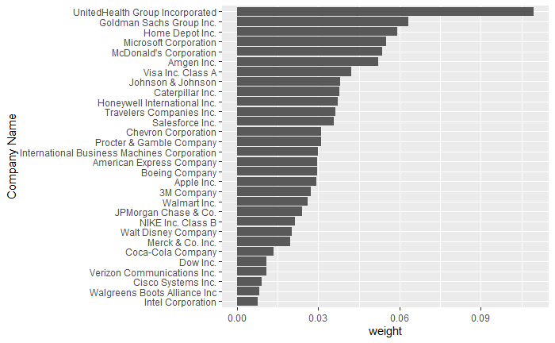

```r
#fig.width=12, fig.height=14
index_info %>%
  #arrange(-weight) %>%
  #head(30) %>% # top 50
  ggplot(aes(x = reorder(company, weight), y = weight)) +
  geom_col() +
  coord_flip() +
  xlab("Company Name")
```

Next, get stock info for one company from the tibble and examine the results.

```r
# use tq_get()
tq_get_options()
```

```
 [1] "stock.prices"       "stock.prices.japan" "dividends"          "splits"             "economic.data"      "quandl"
 [7] "quandl.datatable"   "tiingo"             "tiingo.iex"         "tiingo.crypto"      "alphavantager"      "alphavantage"
[13] "rblpapi"
```

We want to use “stock_prices” argument.

```r
df <- tq_get("TSLA",
       get = "stock.prices",
       from = today - 3*365,
       to = today)

head(df)
```

| symbol | date | open | high | low | close | volume | adjusted |
| --- | --- | --- | --- | --- | --- | --- | --- |
| TSLA | 2019-07-08 | 46.248 | 46.450 | 45.732 | 46.068 | 29402500 | 46.068 |
| TSLA | 2019-07-09 | 45.794 | 46.200 | 45.456 | 46.012 | 30954000 | 46.012 |
| TSLA | 2019-07-10 | 46.830 | 47.788 | 46.628 | 47.784 | 45728500 | 47.784 |
| TSLA | 2019-07-11 | 47.628 | 48.300 | 47.160 | 47.720 | 37572000 | 47.720 |
| TSLA | 2019-07-12 | 47.950 | 49.076 | 47.942 | 49.016 | 46002500 | 49.016 |
| TSLA | 2019-07-15 | 49.600 | 50.884 | 48.972 | 50.700 | 55000500 | 50.700 |

Repeat using tidyverse.

```r
df <- index_info %>%
  select(symbol) %>%
  head(1) %>% # Take the first symbol for now
  tq_get(get = "stock.prices",
         from = today - 3*365,
         to = today)
df
```

[output not shown]

[output cut: 746 more lines]

Now we want to create the criteria of selection.

- Calculate and Compare MA200 with MA50
- If MA50 > MA200 then select the stock
- Set time period?

Calculate and compare MA200 and MA50

```r
# select symbol
symbol_col <- df %>%
  select(symbol)

# select date
date_col <- df %>%
  select(date)

# calculate rolling 50
roll_50 <- df %>%
  select(close) %>%
  rollmean(50,
           fill = NA,
           align = "right")

# calculate rolling 200
roll_200 <- df %>%
  select(close) %>%
  rollmean(200,
           fill = NA,
           align = "right")

# Compare the ma 50 and ma 200
df_comp <- data.frame("symbol"   = symbol_col,
                      "date"     = date_col,
                      "ma_50"    = roll_50,
                      "ma_200"   = roll_200)

names(df_comp) <- c("symbol", "date", "ma_50", "ma_200")

# check tail
df_comp %>%
  tail()
```

[output not shown]

```r
# check logic if ma_50 >= ma_200
df_comp %>%
  filter(ma_50 >= ma_200,
         date == max(date))%>%
  select(symbol,date, ma_50, ma_200) # select the date and the max
```

| symbol | date | ma_50 | ma_200 |
| --- | --- | --- | --- |

These are the stocks that we want to plot then. These are potential buy candidates with upside momentum. We should add a filtering criteria for this date, only select the symbols that have the date close to today.

Plot the data

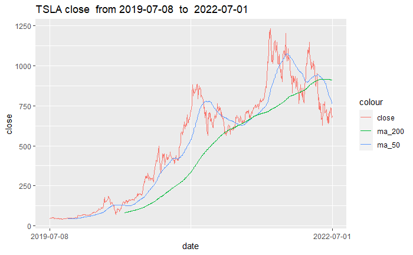

```r
# set start and end date for the plot
b1 <- as.Date(min(df$date))
b2 <- as.Date(max(df$date))

ggplot(df, aes(x = date, y = close, group = 1, col = "close")) +
  geom_line() +
  geom_line(data = df, aes(x = date,
                           y = rollmean(close, 50,
                                        fill = NA,
                                        align = "right"),
                           group = 1,
                           col = "ma_50")) +
  geom_line(data = df, aes(x = date,
                           y = rollmean(close, 200,
                                        fill = NA,
                                        align = "right"),
                           group = 1,
                           col = "ma_200")) +
  scale_x_date(breaks = c(b1,b2)) +
  ggtitle(paste(df[1,1], names(df)[6], " from",b1," to ",b2)) +
  xlab("date") #+
```

```r
  #theme_minimal() +
  #geom_vline(xintercept = t, linetype = 2,  color = "brown", alpha = .5)
```

Next, we loop over the tibble row wise for each company and collect stock info. The stocks that pass the selection criteria, these stocks we want to plot according to above. We could add a proper filter to capture date that is closed to today. The rest of the stocks we don´t care about.

### Loop Construct

```r
# check unique values in index_info
lapply(index_info, function(x) {length(unique(x))})
```

```
$symbol
[1] 30

$company
[1] 30

$identifier
[1] 30

$sedol
[1] 30

$weight
[1] 30

$sector
[1] 9

$shares_held
[1] 2

$local_currency
[1] 1
```

```r
#i <- "HD"

# create two empty df for the results
df_comp_results <- data.frame("symbol" = as.character(),
                              "date"   = as.Date(x = integer(0), origin = "1970-01-01"),
                              "close"  = as.numeric(),
                              "ma_50"  = as.numeric(),
                              "ma_200" = as.numeric())

df_results <- data.frame("symbol" = as.character(),
                         "date"   = as.Date(x = integer(0), origin = "1970-01-01"),
                         "close"  = as.numeric(),
                         "ma_50"  = as.numeric(),
                         "ma_200" = as.numeric())

# loop over each stock in the index_info
for (i in unique(index_info$symbol)) {
  # segment the data
  df <- index_info %>%
    filter(symbol == i) %>%
    select(symbol) %>%
    head(1) %>%
      tq_get(get = "stock.prices",
             from = today - 3*365,
             to = today)

      ## calculate moving averages

      # select symbol
      symbol_col <- df %>%
        select(symbol)

      # select date
      date_col <- df %>%
        select(date)

      # select close
      close <- df %>%
        select(close)

      # calculate rolling 50
      roll_50 <- df %>%
        select(close) %>%
        rollmean(50,
                 fill = NA,
                 align = "right")

      # calculate rolling 200
      roll_200 <- df %>%
        select(close) %>%
        rollmean(200,
                 fill = NA,
                 align = "right")

      # Compare the ma 50 and ma 200
      df_comp <- data.frame("symbol"   = symbol_col,
                            "date"     = date_col,
                            "close"    = close,
                            "ma_50"    = roll_50,
                            "ma_200"   = roll_200)

      names(df_comp) <- c("symbol", "date", "close", "ma_50", "ma_200")

      # check logic if ma_50 >= ma_200
      df_comp_summary <- df_comp %>%
        filter(ma_50 >= ma_200,
               date == max(date))%>%
        select(symbol,date, close, ma_50, ma_200) # select the date and the max

  # bind results
  df_comp_results <- rbind(df_comp_results, df_comp)   # all rows per symbol
  df_results      <- rbind(df_results,df_comp_summary) # one row per symbol
}

# clean up
rm(symbol_col,date_col,roll_50,roll_200,df_comp,df_comp_summary)

# store the df locally
#write.csv2(df_comp, file="df_comp.csv")
```

Create plots

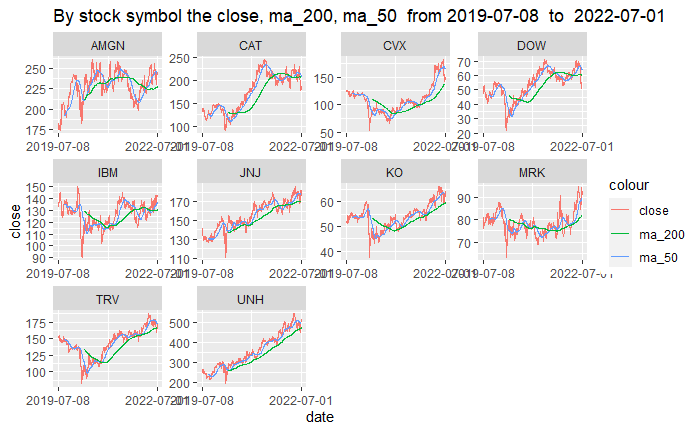

```r
# latest version

# plot only the symbols that are in the df_results
df_plot <- df_comp_results %>%
  filter(symbol %in% unique(df_results$symbol))

# set start and end date for the plot
b1 <- as.Date(min(df_plot$date))
b2 <- as.Date(max(df_plot$date))

df_plot %>%
  ggplot(aes(x = date, y = close, group = 1, col = "close")) +
  geom_line() +
  geom_line(data = df_plot, aes(x = date,
                                y = ma_50,
                                group = 1,
                                col = "ma_50")) +
  geom_line(data = df_plot, aes(x = date,
                                y = ma_200,
                                group = 1,
                                col = "ma_200")) +
  scale_x_date(breaks = c(b1,b2)) +
  ggtitle(paste("By stock symbol the close, ma_200, ma_50"," from",b1," to ",b2)) +
  xlab("date") +
  facet_wrap(~symbol, scales = "free")
```

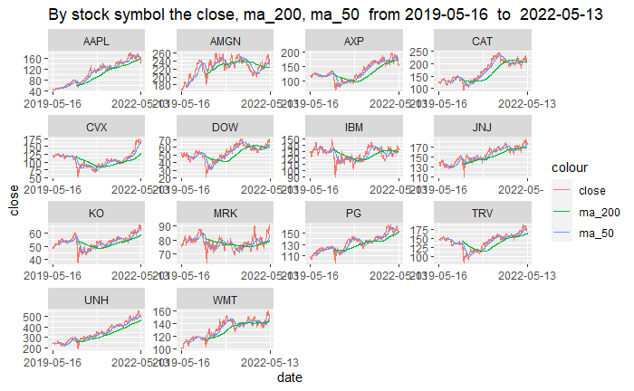

```r
# previous version

# plot only the symbols that are in the df_results
df_plot <- df_comp_results %>%
  filter(symbol %in% unique(df_results$symbol))

# set start and end date for the plot
b1 <- as.Date(min(df_plot$date))
b2 <- as.Date(max(df_plot$date))

df_plot %>%
  ggplot(aes(x = date, y = close, group = 1, col = "close")) +
  geom_line() +
  geom_line(data = df_plot, aes(x = date,
                                y = ma_50,
                                group = 1,
                                col = "ma_50")) +
  geom_line(data = df_plot, aes(x = date,
                                y = ma_200,
                                group = 1,
                                col = "ma_200")) +
  scale_x_date(breaks = c(b1,b2)) +
  ggtitle(paste("By stock symbol the close, ma_200, ma_50"," from",b1," to ",b2)) +
  xlab("date") +
  facet_wrap(~symbol, scales = "free")
```

The above plot contains the stocks that fulfill our selection criteria of ma_50 above ma_200. Next, add what point in time the rule should apply.  
Comment to above plots: There was a major drop in stock prices globally in third week of Jan 2022. Due to Ukraine crisis and Omikron. Several stocks passed the death-cross AXP, CRM, GS, JPM while MRK, TRV are close to it on 2022-02-13. GS, JPM passed death cross while AXP, MRK are still above on 2022-02-23. 2022-02-24 Russia invaded Ukraine. 2022-07-01 Only 10 stocks above death-cross.